# Project: TMDB 5000 Movie Dataset Analysis

- Introduction
- Data Wrangling
- Exploratory Data Analysis
- Conclusions

## Introduction

### Data Description

This data set contains information about 10,000 movies collected from The Movie Database (TMDb), including user ratings and revenue generated for each movie, budget for the movies e.t.c.

The columns in the dataset are:

- **id:** The primary key, unique identifier for each row.
- **imdb_id:** The id for each title on IMDb database.
- **popularity:** A rating metric that is built from various factors. More information can be found on: https://developers.themoviedb.org/3/getting-started/popularity
- **budget:** The stated budget of the film as at when released.
- **revenue:** The total revenue generated from each film.
- **original_title:** The title of each film.
- **cast:** A list of lead cast-members in the film.
- **homepage:** This is the link to each film's website.
- **director:** Contains the names of the lead director, or a list of directors of the film.
- **tagline:** The promotional sentence(s) used fro promoting the films.
- **keywords:** A list of SEO keywords for searching and indexing.
- **overview:** A brief description of the movie's plot.
- **runtime:** The length of the movie in minutes.
- **genres:** A list of genres that the film falls under.
- **production_companies:** The names of companies involved in producing the film.
- **release_date:** The day the film was released.
- **vote_count:** The number of votes given to the film on TMDB.
- **vote_average:** The mean score calculated from all votes.
- **release_year:** The year the film was released.
- **budget_adj:** The film's budget, adjusted for inflation.
- **revenue_adj:** The film's revenue, adjusted for inflation.

### Question(s) for Analysis

**1**: What are the top ten films by popularity?

**2**: What are the top ten films by vote_count?

**3**: Who are the top ten cast in films?

**4**: What are the ten most popular genres of all the films?

**5**: What are the top ten production companies by vote count?

**6**: What are the top ten production companies by popularity?

**7**: Who are the top ten Directors by popularity?

**8**: Who are the top ten Directors by Vote count?

**9**: What are the top ten films by popularity?

**10**: What are the top ten films by vote count?

**11**: What are the top ten films by Adjusted Budget?

**12**: What are the top ten films by Adjusted Revenues?

**13**: What are the top ten films by Adjusted Profit?

**14**: What is the Profit Trends of films over the years?

###### Importing Libraries

```python
import pandas as pd
import numpy as np
import operator
import seaborn as sns
import matplotlib.pyplot as plt
%matplotlib inline

import warnings
```

## Data Wrangling

##### Loading Dataset

- The CSV file was read into pandas firectly from the download source. This was do that the file can be used by any user connected to the internet and I don't have to export a csv file of the dataset with my submission.

```python
# This file was downloaded on the 27th of May, 2022

url = "https://d17h27t6h515a5.cloudfront.net/topher/2017/October/59dd1c4c_tmdb-movies/tmdb-movies.csv"

df = pd.read_csv(url)
```

##### Taking a look into the data frame for the first time

```python
# I choose the first 3 rows to save space
df.head(3)
```

|  | id | imdb_id | popularity | budget | revenue | original_title | cast | homepage | director | tagline | ... | overview | runtime | genres | production_companies | release_date | vote_count | vote_average | release_year | budget_adj | revenue_adj |
| --- | --- | --- | --- | --- | --- | --- | --- | --- | --- | --- | --- | --- | --- | --- | --- | --- | --- | --- | --- | --- | --- |
| 0 | 135397 | tt0369610 | 32.985763 | 150000000 | 1513528810 | Jurassic World | Chris Pratt\|Bryce Dallas Howard\|Irrfan Khan\|Vi... | http://www.jurassicworld.com/ | Colin Trevorrow | The park is open. | ... | Twenty-two years after the events of Jurassic ... | 124 | Action\|Adventure\|Science Fiction\|Thriller | Universal Studios\|Amblin Entertainment\|Legenda... | 6/9/15 | 5562 | 6.5 | 2015 | 1.379999e+08 | 1.392446e+09 |
| 1 | 76341 | tt1392190 | 28.419936 | 150000000 | 378436354 | Mad Max: Fury Road | Tom Hardy\|Charlize Theron\|Hugh Keays-Byrne\|Nic... | http://www.madmaxmovie.com/ | George Miller | What a Lovely Day. | ... | An apocalyptic story set in the furthest reach... | 120 | Action\|Adventure\|Science Fiction\|Thriller | Village Roadshow Pictures\|Kennedy Miller Produ... | 5/13/15 | 6185 | 7.1 | 2015 | 1.379999e+08 | 3.481613e+08 |
| 2 | 262500 | tt2908446 | 13.112507 | 110000000 | 295238201 | Insurgent | Shailene Woodley\|Theo James\|Kate Winslet\|Ansel... | http://www.thedivergentseries.movie/#insurgent | Robert Schwentke | One Choice Can Destroy You | ... | Beatrice Prior must confront her inner demons ... | 119 | Adventure\|Science Fiction\|Thriller | Summit Entertainment\|Mandeville Films\|Red Wago... | 3/18/15 | 2480 | 6.3 | 2015 | 1.012000e+08 | 2.716190e+08 |

3 rows × 21 columns

##### Inspecting the shape of the data

```python
df.shape
```

```
(10866, 21)
```

##### Looking at the statistical overview of the data

```python
df.describe()
```

|  | id | popularity | budget | revenue | runtime | vote_count | vote_average | release_year | budget_adj | revenue_adj |
| --- | --- | --- | --- | --- | --- | --- | --- | --- | --- | --- |
| count | 10866.000000 | 10866.000000 | 1.086600e+04 | 1.086600e+04 | 10866.000000 | 10866.000000 | 10866.000000 | 10866.000000 | 1.086600e+04 | 1.086600e+04 |
| mean | 66064.177434 | 0.646441 | 1.462570e+07 | 3.982332e+07 | 102.070863 | 217.389748 | 5.974922 | 2001.322658 | 1.755104e+07 | 5.136436e+07 |
| std | 92130.136561 | 1.000185 | 3.091321e+07 | 1.170035e+08 | 31.381405 | 575.619058 | 0.935142 | 12.812941 | 3.430616e+07 | 1.446325e+08 |
| min | 5.000000 | 0.000065 | 0.000000e+00 | 0.000000e+00 | 0.000000 | 10.000000 | 1.500000 | 1960.000000 | 0.000000e+00 | 0.000000e+00 |
| 25% | 10596.250000 | 0.207583 | 0.000000e+00 | 0.000000e+00 | 90.000000 | 17.000000 | 5.400000 | 1995.000000 | 0.000000e+00 | 0.000000e+00 |
| 50% | 20669.000000 | 0.383856 | 0.000000e+00 | 0.000000e+00 | 99.000000 | 38.000000 | 6.000000 | 2006.000000 | 0.000000e+00 | 0.000000e+00 |
| 75% | 75610.000000 | 0.713817 | 1.500000e+07 | 2.400000e+07 | 111.000000 | 145.750000 | 6.600000 | 2011.000000 | 2.085325e+07 | 3.369710e+07 |
| max | 417859.000000 | 32.985763 | 4.250000e+08 | 2.781506e+09 | 900.000000 | 9767.000000 | 9.200000 | 2015.000000 | 4.250000e+08 | 2.827124e+09 |

##### Getting to know the data type and missing values in the data set

```python
df.info()
```

```
<class 'pandas.core.frame.DataFrame'>
RangeIndex: 10866 entries, 0 to 10865
Data columns (total 21 columns):
id                      10866 non-null int64
imdb_id                 10856 non-null object
popularity              10866 non-null float64
budget                  10866 non-null int64
revenue                 10866 non-null int64
original_title          10866 non-null object
cast                    10790 non-null object
homepage                2936 non-null object
director                10822 non-null object
tagline                 8042 non-null object
keywords                9373 non-null object
overview                10862 non-null object
runtime                 10866 non-null int64
genres                  10843 non-null object
production_companies    9836 non-null object
release_date            10866 non-null object
vote_count              10866 non-null int64
vote_average            10866 non-null float64
release_year            10866 non-null int64
budget_adj              10866 non-null float64
revenue_adj             10866 non-null float64
dtypes: float64(4), int64(6), object(11)
memory usage: 1.7+ MB
```

### Some Observations from the data description.

- Total rows are 10866.
- Total columns are 21.

#### Observations for missing values

- *imdb_id* has 10 missing rows.
- *cast* has 76 missing rows.
- *homepage* has 7930 missing rows.
- *director* has 44 missing rows.
- *tagline* has 2824 missing rows.
- *keywords* has 1493 missing rows.
- *overview* has 4 missing rows.
- *genres* has 23 missing rows.
- *production_companies* has 1030 missing rows.

#### Observations for duplicate rows

- There is one duplicate row

#### Other Observations

- *budjet*, *revenue*, _budjet*adj* and _revenue*adj* all have scientific notation values.
- release_date should be coverted to datetime.
- Some rows of budget, revenue, runtinr, budget_adj, revenue_adj have zero values.

## Data Cleaning

##### From here on, I attempt to clean the data so that my analysis of the above stated question can be fruitful!

##### Dropping coloumns that are not relevant to the analysis

```python
dropped_cols = ["id", "imdb_id","budget",
                "revenue", "homepage", "tagline",
                "overview", "keywords", "runtime",
                "release_date", "vote_average"]

df.drop(dropped_cols, axis=1, inplace=True)
```

##### Confirming that the Columns were dropped

```python
for phrase in dropped_cols:
    assert phrase not in df.columns.values
```

##### Checking the data for duplicates

```python
df.duplicated().sum()
```

```
1
```

##### Dropping and confirming the duplicates were dropped

```python
df.drop_duplicates(inplace=True)
df.duplicated().sum()
```

```
0
```

#### Creating the profit column from revenue_adj and budget_adj

```python
df['profit_adj'] = df['revenue_adj'] - df['budget_adj']
```

#### Changing and confirming that columns displaying scientific notation has been corrected to 2 decimal places

```python
sci_not_change = df[['popularity', 'budget_adj', 'revenue_adj', 'profit_adj']]
sci_not_change = pd.options.display.float_format = '{:5,.2f}'.format

df.describe()
```

|  | popularity | vote_count | release_year | budget_adj | revenue_adj | profit_adj |
| --- | --- | --- | --- | --- | --- | --- |
| count | 10,865.00 | 10,865.00 | 10,865.00 | 10,865.00 | 10,865.00 | 10,865.00 |
| mean | 0.65 | 217.40 | 2,001.32 | 17,549,894.04 | 51,369,001.76 | 33,819,107.72 |
| std | 1.00 | 575.64 | 12.81 | 34,307,526.66 | 144,638,333.13 | 125,219,383.58 |
| min | 0.00 | 10.00 | 1,960.00 | 0.00 | 0.00 | -413,912,431.00 |
| 25% | 0.21 | 17.00 | 1,995.00 | 0.00 | 0.00 | 0.00 |
| 50% | 0.38 | 38.00 | 2,006.00 | 0.00 | 0.00 | 0.00 |
| 75% | 0.71 | 146.00 | 2,011.00 | 20,853,251.08 | 33,701,729.01 | 12,930,907.79 |
| max | 32.99 | 9,767.00 | 2,015.00 | 425,000,000.00 | 2,827,123,750.41 | 2,750,136,650.92 |

###### Dropping null value

```python
df.dropna(inplace=True)
df.shape
```

```
(9772, 11)
```

##### Confirming that null values have been dropped

```python
df.isnull().sum()
```

```
popularity              0
original_title          0
cast                    0
director                0
genres                  0
production_companies    0
vote_count              0
release_year            0
budget_adj              0
revenue_adj             0
profit_adj              0
dtype: int64
```

```python
df.hist(figsize=(10, 8));
```

[output not shown]

### Saving the clean data

```python
## write the updated dataframe to a csv
df.to_csv('clean_film_data.csv', index=False)
```

### Reading the Cleaned Data

```python
df = pd.read_csv('clean_film_data.csv')
```

## Exploratory Data Analysis

### Question #1: What are the top ten films by popularity?

```python
top_films_by_pop = df.sort_values(by = ['popularity'],ascending = False)[['original_title','popularity']].head(10)
top_films_by_pop.reset_index(drop=True,inplace=True)
top_films_by_pop.set_index('original_title', inplace=True)
top_films_by_pop.head(10)
```

| original_title | popularity |
| --- | --- |
| Jurassic World | 32.99 |
| Mad Max: Fury Road | 28.42 |
| Interstellar | 24.95 |
| Guardians of the Galaxy | 14.31 |
| Insurgent | 13.11 |
| Captain America: The Winter Soldier | 12.97 |
| Star Wars | 12.04 |
| John Wick | 11.42 |
| Star Wars: The Force Awakens | 11.17 |
| The Hunger Games: Mockingjay - Part 1 | 10.74 |

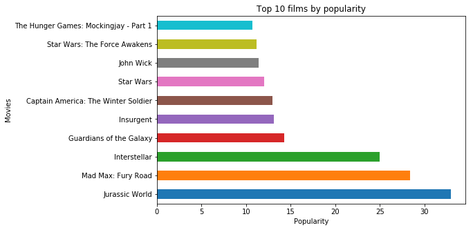

```python
# Plotting the bar
top_films_by_pop.head(10).popularity.plot(kind='barh', figsize=(8, 5), fontsize=10)
plt.xlabel('Popularity')
plt.ylabel('Movies')
plt.title('Top 10 films by popularity');
```

### Question #2: What are the top ten films by vote_count?

```python
top_voted_films = df.sort_values(by = ['vote_count'],ascending = False)[['original_title','vote_count']].head(10)
top_voted_films.reset_index(drop=True,inplace=True)
top_voted_films.set_index('original_title',inplace=True)
top_voted_films
```

| original_title | vote_count |
| --- | --- |
| Inception | 9767 |
| The Avengers | 8903 |
| Avatar | 8458 |
| The Dark Knight | 8432 |
| Django Unchained | 7375 |
| The Hunger Games | 7080 |
| Iron Man 3 | 6882 |
| The Dark Knight Rises | 6723 |
| Interstellar | 6498 |
| The Hobbit: An Unexpected Journey | 6417 |

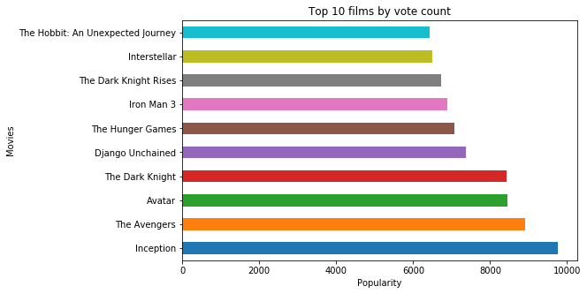

```python
# Plotting the bar
top_voted_films.head(10)['vote_count'].plot(kind='barh', figsize=(8, 5), fontsize=10)
plt.xlabel('Popularity')
plt.ylabel('Movies')
plt.title('Top 10 films by vote count');
```

#### Function to split data by columns name and seperator

```python
def cols_split(df, column, sep='|', keep=False):
    """
    Split the values of a column and expand so the new DataFrame has one split
    value per row. Filters rows where the column is missing.

    """
    indexes = list()
    new_splits = list()

    for i, before_split in enumerate(df[column].astype(str)):
        values = before_split.split(sep)
        if keep and len(values) > 1:
            indexes.append(i)
            new_splits.append(presplit)
        for value in values:
            indexes.append(i)
            new_splits.append(value)
    new_df = df.iloc[indexes, :].copy()
    new_df[column] = new_splits
    return new_df
```

### Question #3: Who are the top ten cast in films?

```python
actor_casting = cols_split(df, 'cast', '|').cast.value_counts().sort_values(ascending=False).head(10)
actor_casting
```

```
Robert De Niro       72
Samuel L. Jackson    70
Bruce Willis         62
Nicolas Cage         61
Michael Caine        52
Robin Williams       51
Morgan Freeman       49
John Goodman         48
John Cusack          48
Liam Neeson          47
Name: cast, dtype: int64
```

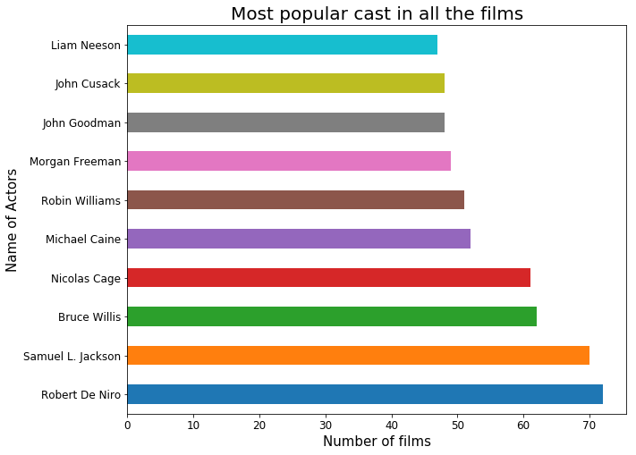

```python
# Plotting the bar
plt.figure(figsize=(10,5));

actor_casting.head(10).plot.barh(figsize=(10, 8), fontsize=12)
plt.title("Most popular cast in all the films", size=20)
plt.xlabel("Number of films", size=15)
plt.ylabel("Name of Actors", size=15);
```

### Question #4: What are the ten most popular genres of all the films?

```python
top_genre = cols_split(df, 'genres', '|').genres.value_counts().sort_values(ascending=False).head(10)
top_genre
```

```
Drama              4364
Comedy             3433
Thriller           2746
Action             2235
Romance            1570
Horror             1526
Adventure          1384
Crime              1299
Science Fiction    1136
Family             1095
Name: genres, dtype: int64
```

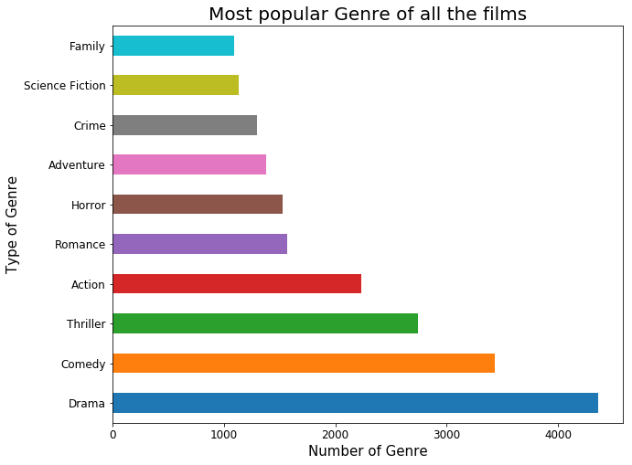

```python
# Plotting the bar
plt.figure(figsize=(10,5));

top_genre.head(10).plot.barh(figsize=(10, 8), fontsize=12)
plt.title("Most popular Genre of all the films", size=20)
plt.xlabel("Number of Genre", size=15)
plt.ylabel("Type of Genre", size=15);
```

### Question 5. What are the top ten production companies by vote count?

```python
top_prod_comp = cols_split(df, 'production_companies', '|').groupby('production_companies')['vote_count'].mean().to_frame().sort_values(ascending=False, by=['vote_count']).head(10)

top_prod_comp
```

| production_companies | vote_count |
| --- | --- |
| Atman Entertainment | 5,923.00 |
| Linson Films | 5,923.00 |
| Bulletproof Cupid | 5,612.00 |
| Truenorth Productions | 5,292.00 |
| Syncopy | 5,032.00 |
| IFP Westcoast Erste | 4,134.00 |
| EMJAG Productions | 4,027.00 |
| Alfran Productions | 3,970.00 |
| Visiona Romantica | 3,969.00 |
| Zehnte Babelsberg | 3,969.00 |

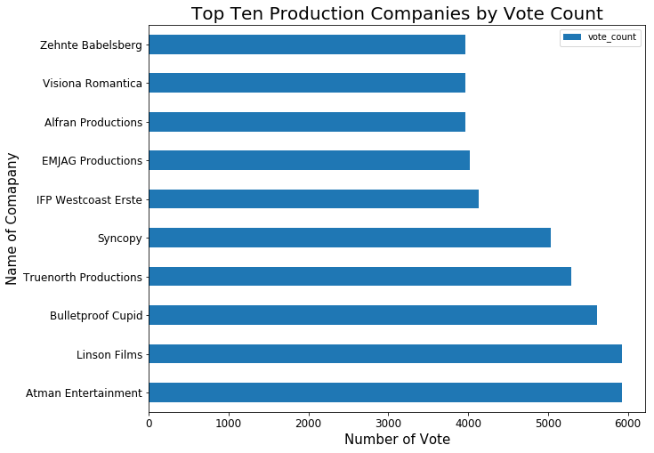

```python
# Plotting the bar
plt.figure(figsize=(10,5));

top_prod_comp.head(10).plot.barh(figsize=(10, 8), fontsize=12)
plt.title("Top Ten Production Companies by Vote Count", size=20)
plt.ylabel("Name of Comapany", size=15)
plt.xlabel("Number of Vote", size=15);
```

### Question 6. What are the top ten production companies by popularity?

```python
top_prod_pop = cols_split(df, 'production_companies', '|').groupby('production_companies')['popularity'].mean().to_frame().sort_values(
    ascending=False, by=['popularity']).head(10)

top_prod_pop
```

| production_companies | popularity |
| --- | --- |
| Bulletproof Cupid | 14.31 |
| Fuji Television Network | 12.78 |
| DefyNite Films | 11.42 |
| Truenorth Productions | 11.17 |
| 3Foot7 | 10.17 |
| Linson Films | 8.95 |
| Atman Entertainment | 8.95 |
| Bristol Automotive | 8.11 |
| Dayday Films | 7.14 |
| Syncopy | 7.05 |

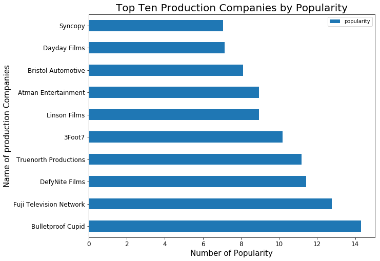

```python
# Plotting the bar
plt.figure(figsize=(10,5));

top_prod_pop.plot.barh(figsize=(10, 8), fontsize=12)
plt.title("Top Ten Production Companies by Popularity", size=20)
plt.xlabel("Number of Popularity", size=15)
plt.ylabel("Name of production Companies", size=15);
```

### Question #7: Who are the top ten Directors by popularity?

```python
top_dir_pop = cols_split(df, 'director', '|').groupby('director').popularity.mean().to_frame().sort_values(ascending=False, by=['popularity']).head(10)

top_dir_pop
```

| director | popularity |
| --- | --- |
| Colin Trevorrow | 16.70 |
| David Leitch | 11.42 |
| Chad Stahelski | 11.42 |
| Alan Taylor | 6.88 |
| Christopher Nolan | 6.87 |
| Alex Garland | 6.12 |
| Patrick Tatopoulos | 5.81 |
| Wes Ball | 5.55 |
| Dan Gilroy | 5.52 |
| David Yates | 5.13 |

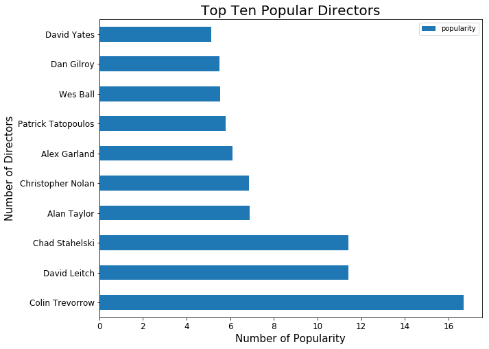

```python
# Plotting the bar
plt.figure(figsize=(10,5));

top_dir_pop.plot.barh(figsize=(10, 8), fontsize=12)
plt.title("Top Ten Popular Directors", size=20)
plt.ylabel("Number of Directors", size=15)
plt.xlabel("Number of Popularity", size=15);
```

### Question 8. Who are the top ten Directors by Vote count?

```python
top_dir_rate =cols_split(df, 'director', '|').groupby('director')['vote_count'].mean().to_frame().sort_values(
    ascending=False,
    by=['vote_count']
    ).head(10)

top_dir_rate
```

| director | vote_count |
| --- | --- |
| Joss Whedon | 4,673.67 |
| Christopher Nolan | 4,634.67 |
| Bob Peterson | 4,225.00 |
| Pierre Coffin | 3,726.67 |
| Shane Black | 3,704.50 |
| Rich Moore | 3,492.00 |
| David Yates | 3,454.75 |
| Mark Andrews | 3,206.00 |
| Lee Unkrich | 3,196.75 |
| Marc Webb | 3,142.67 |

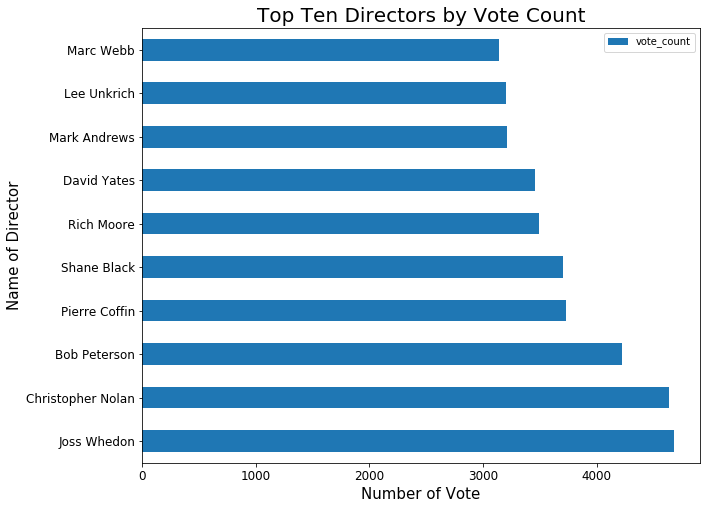

```python
# Plotting the bar
plt.figure(figsize=(10,5));

top_dir_rate.plot.barh(figsize=(10, 8), fontsize=12)
plt.title("Top Ten Directors by Vote Count", size=20)
plt.xlabel("Number of Vote", size=15)
plt.ylabel("Name of Director", size=15);
```

### Question #9. What are the top ten films by popularity?

```python
top_films_pop = df.sort_values(by = ['popularity'],ascending = False)[['original_title','popularity']].head(10)
top_films_pop.reset_index(drop=True,inplace=True)
top_films_pop.set_index('original_title',inplace=True)
top_films_pop
```

| original_title | popularity |
| --- | --- |
| Jurassic World | 32.99 |
| Mad Max: Fury Road | 28.42 |
| Interstellar | 24.95 |
| Guardians of the Galaxy | 14.31 |
| Insurgent | 13.11 |
| Captain America: The Winter Soldier | 12.97 |
| Star Wars | 12.04 |
| John Wick | 11.42 |
| Star Wars: The Force Awakens | 11.17 |
| The Hunger Games: Mockingjay - Part 1 | 10.74 |

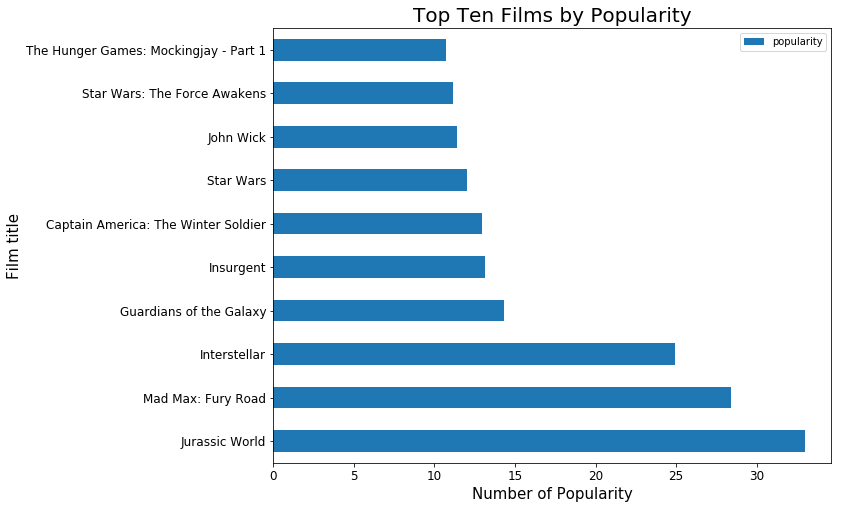

```python
# Plotting the bar
plt.figure(figsize=(10,5));

top_films_pop.plot.barh(figsize=(10, 8), fontsize=12)
plt.title("Top Ten Films by Popularity", size=20)
plt.ylabel("Film title", size=15)
plt.xlabel("Number of Popularity", size=15);
```

### Question #10. What are the top ten films by vote_count?

```python
top_films_vote = df.sort_values(by = ['vote_count'],ascending = False)[['original_title','vote_count']].head(10)
top_films_vote.reset_index(drop=True,inplace=True)
top_films_vote.set_index('original_title',inplace=True)
top_films_vote
```

| original_title | vote_count |
| --- | --- |
| Inception | 9767 |
| The Avengers | 8903 |
| Avatar | 8458 |
| The Dark Knight | 8432 |
| Django Unchained | 7375 |
| The Hunger Games | 7080 |
| Iron Man 3 | 6882 |
| The Dark Knight Rises | 6723 |
| Interstellar | 6498 |
| The Hobbit: An Unexpected Journey | 6417 |

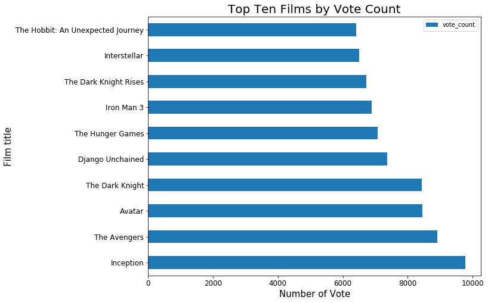

```python
# Plotting the bar
plt.figure(figsize=(10,5));

top_films_vote.plot.barh(figsize=(10, 8), fontsize=12)
plt.title("Top Ten Films by Vote Count", size=20)
plt.ylabel("Film title", size=15)
plt.xlabel("Number of Vote", size=15);
```

### Question #11. What are the top ten films by Adjusted Budget?

```python
top_films_by_budget = df.sort_values(by = ['budget_adj'],ascending = False)[['original_title','budget_adj']].head(10)
top_films_by_budget.reset_index(drop=True,inplace=True)
top_films_by_budget.set_index('original_title', inplace=True)
top_films_by_budget.head(10)
```

| original_title | budget_adj |
| --- | --- |
| The Warrior's Way | 425,000,000.00 |
| Pirates of the Caribbean: On Stranger Tides | 368,371,256.18 |
| Pirates of the Caribbean: At World's End | 315,500,574.79 |
| Superman Returns | 292,050,672.74 |
| Titanic | 271,692,064.21 |
| Spider-Man 3 | 271,330,494.32 |
| Tangled | 260,000,000.00 |
| Avengers: Age of Ultron | 257,599,886.66 |
| Harry Potter and the Half-Blood Prince | 254,100,108.53 |
| Waterworld | 250,419,201.74 |

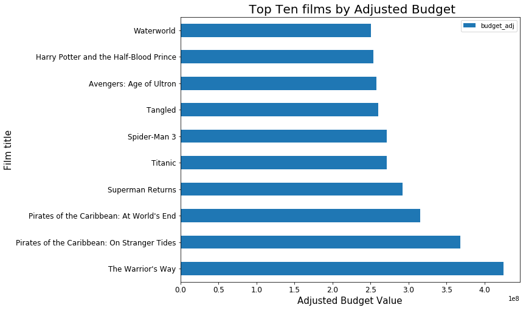

```python
# Plotting the bar
plt.figure(figsize=(10,5));

top_films_by_budget.plot.barh(figsize=(10, 8), fontsize=12)
plt.title(" Top Ten films by Adjusted Budget", size=20)
plt.ylabel("Film title", size=15)
plt.xlabel("Adjusted Budget Value", size=15);
```

### Question #12. What are the top ten films by Adjusted Revenues

```python
top_films_by_revenue = df.sort_values(by = ['revenue_adj'],ascending = False)[['original_title','revenue_adj']].head(10)
top_films_by_revenue.reset_index(drop=True,inplace=True)
top_films_by_revenue.set_index('original_title', inplace=True)
top_films_by_revenue.head(10)
```

| original_title | revenue_adj |
| --- | --- |
| Avatar | 2,827,123,750.41 |
| Star Wars | 2,789,712,242.28 |
| Titanic | 2,506,405,735.42 |
| The Exorcist | 2,167,324,901.20 |
| Jaws | 1,907,005,841.92 |
| Star Wars: The Force Awakens | 1,902,723,129.80 |
| E.T. the Extra-Terrestrial | 1,791,694,309.25 |
| The Net | 1,583,049,536.35 |
| One Hundred and One Dalmatians | 1,574,814,739.70 |
| The Avengers | 1,443,191,435.21 |

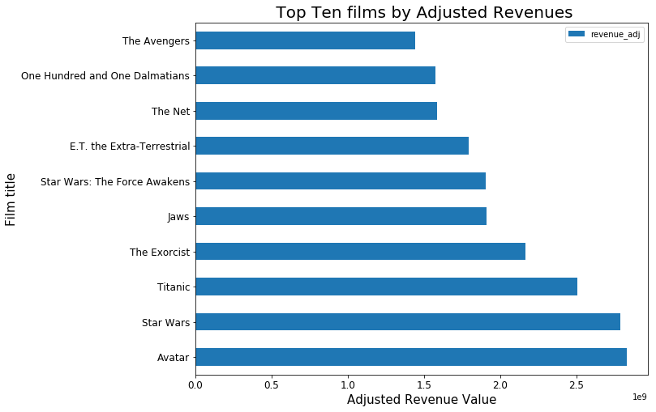

```python
# Plotting the bar
plt.figure(figsize=(10,5));

top_films_by_revenue.plot.barh(figsize=(10, 8), fontsize=12),
plt.title(" Top Ten films by Adjusted Revenues", size=20),
plt.ylabel("Film title", size=15),
plt.xlabel("Adjusted Revenue Value", size=15);
```

### Question #13. What are the top ten films by Profit?

```python
top_films_by_profit = df.sort_values(by = ['profit_adj'],ascending = False)[['original_title','profit_adj']].head(10)
top_films_by_profit.reset_index(drop=True,inplace=True)
top_films_by_profit.set_index('original_title', inplace=True)
top_films_by_profit.head(10)
```

| original_title | profit_adj |
| --- | --- |
| Star Wars | 2,750,136,650.92 |
| Avatar | 2,586,236,847.52 |
| Titanic | 2,234,713,671.21 |
| The Exorcist | 2,128,035,624.57 |
| Jaws | 1,878,643,093.71 |
| E.T. the Extra-Terrestrial | 1,767,968,064.02 |
| Star Wars: The Force Awakens | 1,718,723,210.76 |
| The Net | 1,551,568,265.28 |
| One Hundred and One Dalmatians | 1,545,635,294.87 |
| The Empire Strikes Back | 1,376,997,526.22 |

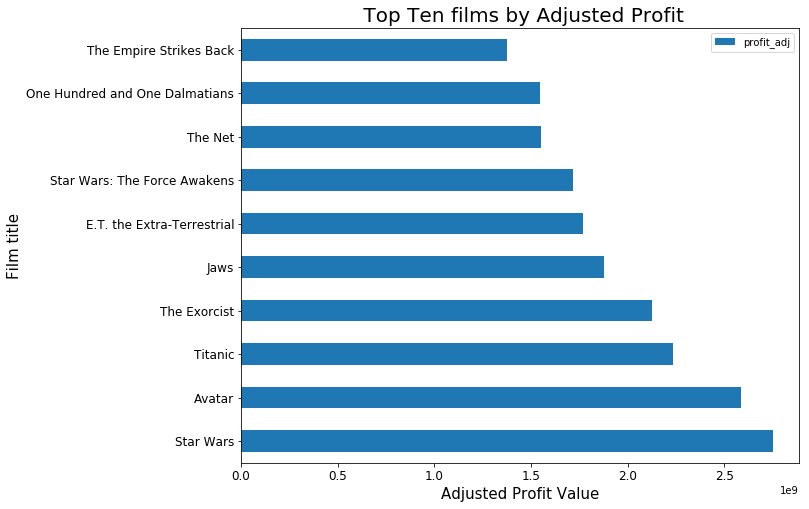

```python
# Plotting the bar
plt.figure(figsize=(10,5));

top_films_by_profit.plot.barh(figsize=(10, 8), fontsize=12)
plt.title(" Top Ten films by Adjusted Profit", size=20)
plt.ylabel("Film title", size=15)
plt.xlabel("Adjusted Profit Value", size=15);
```

### Question #14. What is the Profit Trends of films over the years?

```python
def profit_trend(column_x,column_y):

    #set graph size
    plt.figure(figsize=(10,8), dpi = 100)

    #plotting the graph with matplotlib.pyplot
    plt.plot(df.groupby(column_x)[column_y].sum())
    df.groupby(column_x)[column_y].sum().describe()
    max_value = df.groupby(column_x)[column_y].sum().idxmax()
    min_value = df.groupby(column_x)[column_y].sum().idxmin()

    return max_value,min_value,plt
```

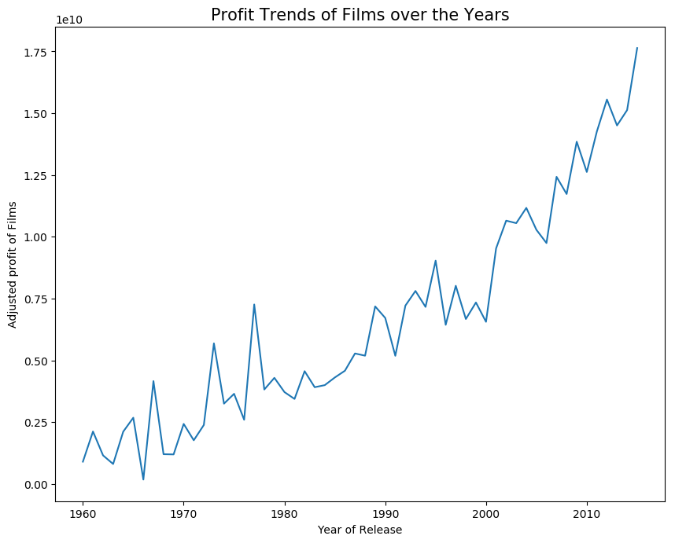

```
The most profitable year is: 2015
The least profitable year is: 1966
```

```python
maxval,minval,plt=profit_trend('release_year','profit_adj')

# Plotting the graph
plt.xlabel('Year of Release', fontsize = 10)
plt.ylabel('Adjusted profit of Films', fontsize = 10)
plt.title('Profit Trends of Films over the Years', fontsize = 15)
plt.show()

print('The most profitable year is:',maxval)
print('The least profitable year is:',minval)
```

## Conclusions

### Limitations of the Findings

One major limitation of this analysis is stated below:

- It is difficult to clearly define the correlation between the popularity nd vote_count of either a film, a production company or a director. An attempt to runn correlations by these analysis will most likely return an ambigous error.

### References:

> The idea for one of the function defined herein was developed from https://stackoverflow.com/questions/12680754/split-explode-pandas-dataframe-string-entry-to-separate-rows

> https://www.geeksforgeeks.org/plot-a-pie-chart-in-python-using-matplotlib/

> https://stackoverflow.com/questions/12680754/split-explode-pandas-dataframe-string-entry-to-separate-rows

```python
from subprocess import call
call(['python', '-m', 'nbconvert', 'Investigate_a_Dataset.ipynb'])
```

```
0
```